# Data Science With R-Project Healthcare - Simplilearn

# Task 3

To make sure that there is no malpractice, the agency needs to analyze if the race of the patient is related to the hospitalization costs.

Here, we have RACE - Categorical variable

Cost - Continuous variable

To find the relation between such combination, we can use ANOVA test

And we are doing the Hypothesis Testing

Null Hypothesis H0: RACE has No Effect on Costs

Alternate Hypothesis Ha : RACE has Effect on Costs

To REJECT the H0, we need enough evidences, means, a striking difference between the both.

In ANOVA, we have F-statistic

## Step 1

Data Wrangling/Cleaning

We need to clean up the entries with values NA in any column ## Step 2

Apply ANOVA test R function, on TOTCHG as Dependent, RACE as independent variable

```r
anyNA(hospital_data) #this tells TRUE
```

```
## [1] TRUE
```

```r
anyNA(hospital_data$RACE) #RACE has some NA entries
```

```
## [1] TRUE
```

```r
summary(hospital_data$RACE) # 1 NA value, we can omit this, as we have no way to predict this as we do for numerical variables
```

```
##    Min. 1st Qu.  Median    Mean 3rd Qu.    Max.    NA's
##   1.000   1.000   1.000   1.078   1.000   6.000       1
```

```r
hospital_data<-na.omit(hospital_data)
anyNA(hospital_data) #Now we have no NA values
```

```
## [1] FALSE
```

```r
#ready to test ANOVA now
model_race_vost_aov<-aov(hospital_data$TOTCHG~hospital_data$RACE)
summary(model_race_vost_aov)
```

```
##                     Df    Sum Sq  Mean Sq F value Pr(>F)
## hospital_data$RACE   1 2.488e+06  2488459   0.164  0.686
## Residuals          497 7.540e+09 15170268
```

## Conclusion

F-statistic is 0.164, and P-value (probability) is 0.686 > 0.05 (significance level), hence we CANNOT REJECT the NULL Hypothesis.

Means RACE HAS NO IMPACT ON COSTS

# Task 4

To properly utilize the costs, the agency has to analyze the severity of the hospital costs by age and gender for the proper allocation of resources.

Hospital wants to understand, whether The Cost Increases/decreases with AGE or GENDER, so we need to find the linear relation among these.

Using Linear Regression model, with TOTCHG as dependent (predicted) variable, GENDER, AGE as independent (predictor) variables

```r
hospital_data$FEMALE<-as.factor(hospital_data$FEMALE)
summary(hospital_data$FEMALE) #almost similar number of MALES and FEMALES
```

```
##   0   1
## 244 255
```

```r
fit_1<-lm(formula =  TOTCHG~AGE+FEMALE,data = hospital_data)
fit_1
```

```
##
## Call:
## lm(formula = TOTCHG ~ AGE + FEMALE, data = hospital_data)
##
## Coefficients:
## (Intercept)          AGE      FEMALE1
##     2719.45        86.04      -744.21
```

```r
summary(fit_1)
```

```
##
## Call:
## lm(formula = TOTCHG ~ AGE + FEMALE, data = hospital_data)
##
## Residuals:
##    Min     1Q Median     3Q    Max
##  -3403  -1444   -873   -156  44950
##
## Coefficients:
##             Estimate Std. Error t value Pr(>|t|)
## (Intercept)  2719.45     261.42  10.403  < 2e-16 ***
## AGE            86.04      25.53   3.371 0.000808 ***
## FEMALE1      -744.21     354.67  -2.098 0.036382 *
## ---
## Signif. codes:  0 '***' 0.001 '**' 0.01 '*' 0.05 '.' 0.1 ' ' 1
##
## Residual standard error: 3849 on 496 degrees of freedom
## Multiple R-squared:  0.02585,    Adjusted R-squared:  0.02192
## F-statistic: 6.581 on 2 and 496 DF,  p-value: 0.001511
```

## Conclusion

We see, p-values for AGE is much lower than significance level, but p-value for Gender is much closer to 0.05.

That means, AGE has bigger impact on costs, although GENDER also is significant for the model.

Coefficient of AGE is higher, means cost is positively increasing with age.

Coefficient of FEMALE 1 is negative, tells, Costs for female patients are lesser as compare to the Males

Lets now plot out model fit_1

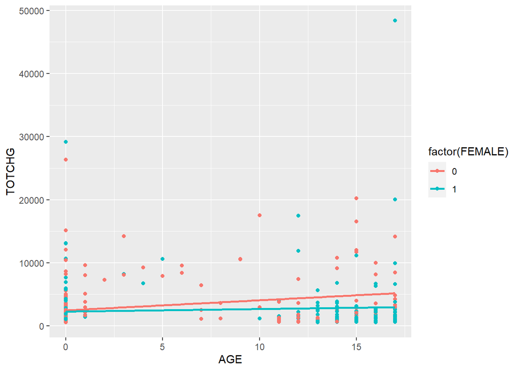

```r
library(ggplot2)
ggplot(hospital_data,aes(y=TOTCHG,x=AGE,color=factor(FEMALE)))+geom_point()+stat_smooth(method="lm",se=FALSE)
```

```r
#The plot clearly defines our regression model, female have lesser costs than males,
#and More the age, more the costs
```

# Task 5

Since the length of stay is the crucial factor for inpatients, the agency wants to find if the length of stay can be predicted from age, gender, and race.

Lets use linear regression to find the relation

```r
hospital_data$RACE<-as.factor(hospital_data$RACE)
hospital_data<-na.omit(hospital_data)
fit_los<-lm(data = hospital_data,formula = LOS~AGE+FEMALE+RACE)
fit_los
```

```
##
## Call:
## lm(formula = LOS ~ AGE + FEMALE + RACE, data = hospital_data)
##
## Coefficients:
## (Intercept)          AGE      FEMALE1        RACE2        RACE3        RACE4
##     2.85687     -0.03938      0.35391     -0.37501      0.78922      0.59493
##       RACE5        RACE6
##    -0.85687     -0.71879
```

```r
summary(fit_los)
```

```
##
## Call:
## lm(formula = LOS ~ AGE + FEMALE + RACE, data = hospital_data)
##
## Residuals:
##    Min     1Q Median     3Q    Max
## -3.211 -1.211 -0.857  0.143 37.789
##
## Coefficients:
##             Estimate Std. Error t value Pr(>|t|)
## (Intercept)  2.85687    0.23160  12.335   <2e-16 ***
## AGE         -0.03938    0.02258  -1.744   0.0818 .
## FEMALE1      0.35391    0.31292   1.131   0.2586
## RACE2       -0.37501    1.39568  -0.269   0.7883
## RACE3        0.78922    3.38581   0.233   0.8158
## RACE4        0.59493    1.95716   0.304   0.7613
## RACE5       -0.85687    1.96273  -0.437   0.6626
## RACE6       -0.71879    2.39295  -0.300   0.7640
## ---
## Signif. codes:  0 '***' 0.001 '**' 0.01 '*' 0.05 '.' 0.1 ' ' 1
##
## Residual standard error: 3.376 on 491 degrees of freedom
## Multiple R-squared:  0.008699,   Adjusted R-squared:  -0.005433
## F-statistic: 0.6156 on 7 and 491 DF,  p-value: 0.7432
```

## Conclusion

None of the predictor variables show significance to the model,

All the p-values are high, thus, Accepting the Null Hypothesis

Concluding that Length of stay cannot be predicted by AGE, RACE, or GENDER

# Task 6

To perform a complete analysis, the agency wants to find the variable that mainly affects hospital costs.

Predict Costs, with all other independent variables.

```r
fit_costs_all<-lm(data = hospital_data,formula = TOTCHG~AGE+FEMALE+RACE+APRDRG+LOS)
fit_costs_all
```

```
##
## Call:
## lm(formula = TOTCHG ~ AGE + FEMALE + RACE + APRDRG + LOS, data = hospital_data)
##
## Coefficients:
## (Intercept)          AGE      FEMALE1        RACE2        RACE3        RACE4
##    5024.961      133.221     -392.578      458.243      330.518     -499.382
##       RACE5        RACE6       APRDRG          LOS
##   -1784.578     -594.292       -7.818      742.964
```

```r
summary(fit_costs_all)
```

```
##
## Call:
## lm(formula = TOTCHG ~ AGE + FEMALE + RACE + APRDRG + LOS, data = hospital_data)
##
## Residuals:
##    Min     1Q Median     3Q    Max
##  -6367   -691   -186    121  43412
##
## Coefficients:
##               Estimate Std. Error t value Pr(>|t|)
## (Intercept)  5024.9610   440.1366  11.417  < 2e-16 ***
## AGE           133.2207    17.6662   7.541 2.29e-13 ***
## FEMALE1      -392.5778   249.2981  -1.575    0.116
## RACE2         458.2427  1085.2320   0.422    0.673
## RACE3         330.5184  2629.5121   0.126    0.900
## RACE4        -499.3818  1520.9293  -0.328    0.743
## RACE5       -1784.5776  1532.0048  -1.165    0.245
## RACE6        -594.2921  1859.1271  -0.320    0.749
## APRDRG         -7.8175     0.6881 -11.361  < 2e-16 ***
## LOS           742.9637    35.0464  21.199  < 2e-16 ***
## ---
## Signif. codes:  0 '***' 0.001 '**' 0.01 '*' 0.05 '.' 0.1 ' ' 1
##
## Residual standard error: 2622 on 489 degrees of freedom
## Multiple R-squared:  0.5544, Adjusted R-squared:  0.5462
## F-statistic:  67.6 on 9 and 489 DF,  p-value: < 2.2e-16
```

## Conclusion

AGE, LOS, APRDRG affect the costs for hospitals, none other does.

LOS has positive relation with Costs.